# Predicción de Abandono de Clientes Utilizando Técnicas de Machine Learning y Deep Learning

# Índice

1. Introducción
   - 1.1 Contexto y Motivación
   - 1.2 Objetivos del Estudio
   - 1.3 Estructura del Trabajo
2. Revisión de la Literatura
   - 2.1 Estudio del Abandono de Clientes
   - 2.2 Métodos Avanzados de Modelado para Churn
   - 2.3 Desafíos y Problemas Comunes en el Análisis de Churn
   - 2.4 Conclusiones sobre la Revisión de la Literatura
3. Descripción del Dataset
   - 3.1 Origen y Descripción del Dataset
   - 3.2 Características del Dataset
   - 3.3 Análisis Exploratorio de Datos (EDA))
   - 3.4 Análisis de Variables Clave
   - 3.5 Matriz de Correlación
   - 3.6 Correlación de Características Independientes
4. Modelado Predictivo
   - 4.1 Selección de Modelos
   - 4.2 Resultados y Comparación de Modelos
   - 4.3 Visualización de Resultados
   - 4.4 Conclusión
5. Interpretación de los Resultados del Modelo Optimizado (XGBoost) )
   - 5.1 Ajuste de Hiperparámetros
   - 5.2 Evaluación del Modelo Optimizado
   - 5.3 Reporte de Clasificación
   - 5.4 Matriz de Confusión
   - 5.5 Conclusión
6. Modelo de Deep Learning para la Predicción de Abandono
   - 6.1 Arquitectura y Entrenamiento del Modelo
   - 6.2 Evaluación del Modelo en el Conjunto de Prueba
   - 6.3 Matriz de Confusión
   - 6.4 Conclusiones sobre el Modelo de Deep Learning
7. Productivización del Modelo de Predicción de Abandono de Clientes
   - 7.1 Creación de una API para la Predicción de Abandono
   - 7.2 Integración Empresarial
   - 7.3 Monitorización y Mantenimiento del Modelo
   - 7.4 Comparación de Modelos y Elección Final
   - 7.5 Conclusión
8. Conclusiones
   - 8.1 Resumen de Hallazgos
   - 8.2 Implicaciones Prácticas
   - 8.3 Recomendaciones para Futuros Trabajos
   - 8.4 Conclusión Final

# **1. Introducción**

## 1.1 Contexto y Motivación

La pérdida de clientes, conocida como **churn**, representa uno de los mayores retos para las empresas que operan en mercados competitivos y dinámicos, como los sectores de telecomunicaciones, banca, comercio electrónico y software como servicio (SaaS). Este fenómeno se manifiesta cuando los clientes deciden finalizar su relación con una empresa o dejar de utilizar sus servicios, lo cual tiene implicaciones significativas para la sostenibilidad del negocio.

El impacto del **churn** no se limita únicamente a la reducción de ingresos; también dificulta el crecimiento empresarial, incrementa los costos de adquisición de nuevos clientes y debilita la fidelización. Estudios han demostrado que retener a los clientes existentes es considerablemente más económico que captar nuevos, lo que resalta la importancia de enfocarse en estrategias de retención proactivas.

En este contexto, analizar el comportamiento de los clientes y sus datos históricos resulta crucial para identificar señales tempranas de abandono. Las herramientas de análisis de datos y los modelos predictivos basados en **Machine Learning** han demostrado ser aliados estratégicos en la lucha contra el **churn**. Estas tecnologías permiten analizar grandes volúmenes de información, detectar patrones complejos y predecir con precisión qué clientes tienen mayor probabilidad de abandonar, lo que facilita la toma de decisiones informadas y personalizadas.

Por lo tanto, este trabajo busca contribuir al desarrollo de enfoques analíticos que no solo anticipen el abandono, sino que también ayuden a las empresas a optimizar la experiencia del cliente y reforzar su propuesta de valor.

## 1.2 Objetivos del Estudio

El propósito de este estudio es diseñar un enfoque integral basado en datos para comprender y predecir la pérdida de clientes. Los objetivos específicos son los siguientes:

1. **Análisis Exploratorio**: Investigar un conjunto de datos relacionado con el **churn** para identificar patrones, factores y características clave asociados al abandono de clientes.
2. **Preprocesamiento de Datos**: Implementar técnicas de limpieza, transformación y manejo del desbalance de clases para garantizar que los datos sean adecuados para el modelado predictivo.
3. **Desarrollo de Modelos Predictivos**: Comparar diversos algoritmos de **Machine Learning**, como la regresión logística, árboles de decisión, Random Forest y Gradient Boosting, para identificar el modelo con mejor desempeño.
4. **Evaluación de Resultados**: Interpretar los resultados obtenidos para determinar los factores más influyentes en la probabilidad de abandono.
5. **Propuestas Estratégicas**: Basándose en los hallazgos del análisis, recomendar estrategias para mitigar el abandono de clientes y mejorar su retención.

## 1.3 Estructura del Trabajo

Este estudio está estructurado de la siguiente manera:

- **Revisión de la Literatura**: Se analizarán las investigaciones previas sobre **churn**, con énfasis en los métodos tradicionales y avanzados para abordar este problema, incluyendo técnicas de modelado predictivo.
- **Descripción del Dataset**: Se presentará el conjunto de datos utilizado, definiendo variables clave como frecuencia de uso, retrasos en pagos, llamadas de soporte y tipo de contrato.
- **Preprocesamiento de Datos**: Se explicará el proceso de limpieza, transformación de datos y técnicas aplicadas para abordar el desbalance de clases.
- **Modelado Predictivo**: Se entrenarán y evaluarán varios algoritmos de **Machine Learning**, comparando su desempeño mediante métricas como precisión, recall, AUC-ROC y F1-score.
- **Discusión de Resultados**: Se interpretarán los resultados del análisis predictivo, destacando las características más relevantes y su influencia en el abandono.
- **Recomendaciones Estratégicas**: Se propondrán acciones específicas basadas en los insights obtenidos para minimizar la pérdida de clientes.
- **Conclusiones y Futuras Investigaciones**: Se resumirán los hallazgos clave, las limitaciones del estudio y las posibles direcciones para investigaciones futuras en este campo.

Con este enfoque, el estudio busca no solo comprender los factores que impulsan el abandono de clientes, sino también proporcionar herramientas prácticas y estratégicas que ayuden a las empresas a mejorar su retención, reducir costos y aumentar la sostenibilidad a largo plazo.

# **2. Revisión de la Literatura**

## 2.1 Estudio del Abandono de Clientes

La pérdida de clientes, o **churn**, ha sido ampliamente estudiada en diversas industrias debido a su impacto crítico en la sostenibilidad y rentabilidad empresarial. Tradicionalmente, el análisis de **churn** se enfocaba en métodos descriptivos y estadísticos simples para identificar tendencias en la pérdida de clientes. Sin embargo, estos enfoques carecían de precisión para capturar la complejidad y las múltiples interacciones entre las características de los clientes.

Con el avance de las tecnologías de análisis de datos y el crecimiento exponencial de las bases de datos empresariales, han surgido enfoques más avanzados que permiten modelar patrones complejos en los comportamientos de los clientes. Estos enfoques incluyen el uso de **algoritmos de aprendizaje automático**, análisis de cohortes y modelado predictivo, los cuales han demostrado ser herramientas poderosas para anticipar el abandono de clientes y diseñar estrategias de retención efectivas.

## 2.2 Métodos Avanzados de Modelado para Churn

### **Modelos Supervisados**

Estos modelos se entrenan utilizando datos históricos en los que se conoce si un cliente ha abandonado o no. Entre las técnicas más comunes se incluyen:

- **Regresión Logística**
  - Ofrece interpretabilidad y una base sólida para modelar relaciones lineales entre características y la probabilidad de abandono.
- **Árboles de Decisión**
  - Proveen una representación intuitiva del comportamiento del cliente a través de reglas claras basadas en las características.
- **Random Forest**
  - Combina múltiples árboles de decisión para mejorar la precisión y evitar el sobreajuste.
- **Gradient Boosting (e.g., XGBoost, LightGBM)**
  - Construye modelos secuenciales que corrigen errores anteriores, destacándose por su alto rendimiento en problemas complejos.
- **Redes Neuronales**
  - Capturan relaciones no lineales y patrones ocultos en los datos, aunque requieren un alto volumen de datos y recursos computacionales.

### **Modelos No Supervisados**

En casos donde no se tienen etiquetas, los modelos no supervisados son útiles para identificar patrones o anomalías. Algunos métodos destacados son:

- **Clustering**
  - Algoritmos como K-Means permiten agrupar clientes según similitudes, identificando segmentos en riesgo de abandono.
- **Detección de Anomalías**
  - Modelos como Isolation Forest o el Análisis de Componentes Principales (PCA) destacan comportamientos que se desvían de lo esperado.

## 2.3 Desafíos y Problemas Comunes en el Análisis de Churn

### **1. Desbalance de Clases**

- **Problema:** El churn suele representar una fracción pequeña de los clientes totales, lo que sesga los modelos hacia la clase mayoritaria (clientes que no abandonan).
- **Soluciones:**
  - **Submuestreo:** Reducir los ejemplos de la clase mayoritaria para equilibrar las proporciones.
  - **Sobremuestreo:** Aumentar la clase minoritaria mediante técnicas como **SMOTE** (Synthetic Minority Over-sampling Technique).

### **2. Interpretabilidad de los Modelos**

- **Problema:** Mientras que modelos simples como la regresión logística son fácilmente interpretables, modelos avanzados como Gradient Boosting o redes neuronales tienden a actuar como "cajas negras".
- **Soluciones:**
  - Utilizar métricas de evaluación claras y técnicas visuales para comprender las contribuciones de las características en los modelos.

### **3. Complejidad en el Comportamiento del Cliente**

El comportamiento de los clientes está influenciado por múltiples factores, como:

- **Duración del contrato.**
- **Interacciones recientes con el servicio.**
- **Soporte recibido.**

Modelar estas interacciones requiere enfoques que capturen la dinámica temporal y no lineal en el comportamiento del cliente.

## 2.4 Conclusiones sobre la Revisión de la Literatura

El análisis de **churn** se ha beneficiado significativamente del avance en las técnicas de **Machine Learning**, las cuales permiten identificar patrones complejos y generar estrategias proactivas para la retención de clientes.

Sin embargo, para garantizar que los resultados sean útiles y confiables, es crucial:

1. Abordar el **desbalance de clases**.
2. Diseñar modelos que sean tanto **precisos** como **interpretables**.
3. Explorar cómo las interacciones dinámicas entre los factores influyen en la probabilidad de abandono.

En este trabajo, se explorarán estos métodos avanzados y se aplicarán a un conjunto de datos sobre churn con el objetivo de predecir el abandono de clientes y diseñar estrategias para minimizar su impacto.

# **3. Descripción del Dataset**

## 3.1 Origen y Descripción del Dataset

El conjunto de datos analizado en este estudio tiene como objetivo principal modelar y predecir la **pérdida de clientes (churn)** en empresas de servicios. Este dataset consta de **505,207 registros**, donde cada registro representa a un cliente único con información detallada relacionada con sus características demográficas, patrones de uso, interacción con la empresa y comportamiento financiero.

El dataset está estructurado para proporcionar una visión integral del comportamiento del cliente, lo que facilita la evaluación del rendimiento de los modelos predictivos y su capacidad de generalización. Esto resulta crucial para identificar los factores clave que contribuyen al abandono y diseñar estrategias de retención más efectivas.

## 3.2 Características del Dataset

El conjunto de datos incluye un conjunto amplio de variables agrupadas en categorías principales:

### **1. Datos Demográficos**

- **Age:** Edad del cliente, una variable numérica que puede influir en los patrones de uso y abandono.
- **Gender:** Género del cliente (Masculino o Femenino), una característica categórica que puede reflejar diferencias en comportamiento o necesidades.

### **2. Datos Relacionados con el Uso**

- **Tenure:** Antigüedad del cliente en la empresa, medida en meses. Representa la duración de la relación cliente-empresa y su nivel de fidelidad.
- **Usage_Frequency:** Frecuencia de uso del servicio, una métrica que captura la intensidad de la interacción del cliente con el servicio.

### **3. Datos de Soporte e Interacciones**

- **Support_Calls:** Número de llamadas realizadas al soporte técnico. Esta variable puede indicar niveles de insatisfacción o complejidad en el uso del servicio.
- **Last_Interaction:** Días desde la última interacción del cliente con la empresa, una métrica que puede reflejar el nivel de compromiso o desconexión del cliente.

### **4. Datos Financieros**

- **Payment_Delay:** Días de retraso en los pagos, una métrica clave que podría correlacionarse con el riesgo de abandono.
- **Total_Spend:** Gasto total acumulado del cliente, que puede indicar el nivel de inversión y valor que el cliente asigna al servicio.

### **5. Datos Contractuales**

- **Subscription_Type:** Tipo de suscripción contratada por el cliente (Básico, Estándar o Premium). Esta variable puede reflejar diferentes niveles de compromiso o necesidades de los clientes.
- **Contract_Length:** Duración del contrato (Mensual, Trimestral o Anual). Los clientes con contratos más largos pueden estar más comprometidos y, por lo tanto, ser menos propensos al abandono.

|  | CustomerID | Age | Gender | Tenure | Usage Frequency | Support Calls | Payment Delay | Subscription Type | Contract Length | Total Spend | Last Interaction | Churn |
| --- | --- | --- | --- | --- | --- | --- | --- | --- | --- | --- | --- | --- |
| 0 | 2.0 | 30.0 | Female | 39.0 | 14.0 | 5.0 | 18.0 | Standard | Annual | 932.0 | 17.0 | 1.0 |
| 1 | 3.0 | 65.0 | Female | 49.0 | 1.0 | 10.0 | 8.0 | Basic | Monthly | 557.0 | 6.0 | 1.0 |
| 2 | 4.0 | 55.0 | Female | 14.0 | 4.0 | 6.0 | 18.0 | Basic | Quarterly | 185.0 | 3.0 | 1.0 |
| 3 | 5.0 | 58.0 | Male | 38.0 | 21.0 | 7.0 | 7.0 | Standard | Monthly | 396.0 | 29.0 | 1.0 |
| 4 | 6.0 | 23.0 | Male | 32.0 | 20.0 | 5.0 | 8.0 | Basic | Monthly | 617.0 | 20.0 | 1.0 |
| ... | ... | ... | ... | ... | ... | ... | ... | ... | ... | ... | ... | ... |
| 505202 | 64370.0 | 45.0 | Female | 33.0 | 12.0 | 6.0 | 21.0 | Basic | Quarterly | 947.0 | 14.0 | 1.0 |
| 505203 | 64371.0 | 37.0 | Male | 6.0 | 1.0 | 5.0 | 22.0 | Standard | Annual | 923.0 | 9.0 | 1.0 |
| 505204 | 64372.0 | 25.0 | Male | 39.0 | 14.0 | 8.0 | 30.0 | Premium | Monthly | 327.0 | 20.0 | 1.0 |
| 505205 | 64373.0 | 50.0 | Female | 18.0 | 19.0 | 7.0 | 22.0 | Standard | Monthly | 540.0 | 13.0 | 1.0 |
| 505206 | 64374.0 | 52.0 | Female | 45.0 | 15.0 | 9.0 | 25.0 | Standard | Monthly | 696.0 | 22.0 | 1.0 |

505207 rows × 12 columns

## 3.3 Análisis Exploratorio de Datos (EDA)

```
<class 'pandas.core.frame.DataFrame'>
RangeIndex: 505207 entries, 0 to 505206
Data columns (total 11 columns):
 #   Column             Non-Null Count   Dtype
---  ------             --------------   -----
 0   Age                505206 non-null  float64
 1   Gender             505206 non-null  object
 2   Tenure             505206 non-null  float64
 3   Usage Frequency    505206 non-null  float64
 4   Support Calls      505206 non-null  float64
 5   Payment Delay      505206 non-null  float64
 6   Subscription Type  505206 non-null  object
 7   Contract Length    505206 non-null  object
 8   Total Spend        505206 non-null  float64
 9   Last Interaction   505206 non-null  float64
 10  Churn              505206 non-null  float64
dtypes: float64(8), object(3)
memory usage: 42.4+ MB
```

```
Index(['age', 'gender', 'tenure', 'usage_frequency', 'support_calls',
       'payment_delay', 'subscription_type', 'contract_length', 'total_spend',
       'last_interaction', 'churn'],
      dtype='object')
```

|  | gender | subscription_type | contract_length |
| --- | --- | --- | --- |
| count | 505206 | 505206 | 505206 |
| unique | 2 | 3 | 3 |
| top | Male | Standard | Annual |
| freq | 280273 | 170630 | 198608 |

## 1. Variables Categóricas

El análisis de las variables categóricas revela las siguientes características clave:

### **1.1 Gender**

- **Conteo (Count):** 505,206 registros.
- **Valores únicos (Unique):** 2 (Male y Female).
- **Valor más frecuente (Top):** Male.
- **Frecuencia del valor más frecuente (Freq):** 280,273 registros (55.5% del total).

### **1.2 Subscription_Type**

- **Conteo (Count):** 505,206 registros.
- **Valores únicos (Unique):** 3 (Standard, Basic, Premium).
- **Valor más frecuente (Top):** Standard.
- **Frecuencia del valor más frecuente (Freq):** 170,630 registros (33.8% del total).

### **1.3 Contract_Length**

- **Conteo (Count):** 505,206 registros.
- **Valores únicos (Unique):** 3 (Monthly, Quarterly, Annual).
- **Valor más frecuente (Top):** Annual.
- **Frecuencia del valor más frecuente (Freq):** 198,608 registros (39.3% del total).

### **Observaciones Clave:**

1. La mayoría de los clientes son hombres (**55.5% Male**).
2. El tipo de suscripción más común es "Standard" (**33.8%**).
3. Los contratos anuales son los más frecuentes (**39.3% Annual**), lo que indica un compromiso relativamente alto por parte de muchos clientes.

|  | age | tenure | usage_frequency | support_calls | payment_delay | total_spend | last_interaction | churn |
| --- | --- | --- | --- | --- | --- | --- | --- | --- |
| count | 505206.000000 | 505206.000000 | 505206.000000 | 505206.000000 | 505206.000000 | 505206.000000 | 505206.000000 | 505206.000000 |
| mean | 39.704172 | 31.350435 | 15.714825 | 3.833317 | 13.496843 | 620.072766 | 14.610581 | 0.555203 |
| std | 12.670577 | 17.237482 | 8.619323 | 3.133603 | 8.451187 | 245.319256 | 8.608286 | 0.496944 |
| min | 18.000000 | 1.000000 | 1.000000 | 0.000000 | 0.000000 | 100.000000 | 1.000000 | 0.000000 |
| 25% | 29.000000 | 16.000000 | 8.000000 | 1.000000 | 6.000000 | 446.000000 | 7.000000 | 0.000000 |
| 50% | 40.000000 | 32.000000 | 16.000000 | 3.000000 | 13.000000 | 648.900000 | 14.000000 | 1.000000 |
| 75% | 49.000000 | 46.000000 | 23.000000 | 6.000000 | 20.000000 | 824.000000 | 22.000000 | 1.000000 |
| max | 65.000000 | 60.000000 | 30.000000 | 10.000000 | 30.000000 | 1000.000000 | 30.000000 | 1.000000 |

## 2. Variables Numéricas

- **Edad (`age`)**
  - Rango de edades: **18 a 65 años**, con una media de **39.7 años** y una mediana de **40 años**.
  - La distribución es equilibrada y refleja una base de clientes de diferentes generaciones.
- **Antigüedad (`tenure`)**
  - Promedio de antigüedad: **31.35 meses**, con un máximo de **60 meses**.
  - Representa una mezcla de clientes nuevos y antiguos.
- **Frecuencia de Uso (`usage_frequency`)**
  - Los clientes utilizan el servicio en promedio **15.71 veces al mes**, con un rango de **1 a 30 usos mensuales**.
- **Llamadas de Soporte (`support_calls`)**
  - Promedio de **3.83 llamadas** por cliente, con un máximo de **10 llamadas**.
  - Este indicador podría reflejar insatisfacción o problemas frecuentes con el servicio.
- **Retraso en el Pago (`payment_delay`)**
  - Retraso promedio de **13.5 días**, con un rango de **0 a 30 días**.
  - Puede ser un indicador importante para identificar clientes en riesgo de abandono.
- **Gasto Total (`total_spend`)**
  - Promedio de **620.07** y un máximo de **1,000**.
  - Sugiere una variación significativa en el nivel de inversión de los clientes.
- **Última Interacción (`last_interaction`)**
  - Tiempo promedio desde la última interacción: **14.61 días**, con un rango de **1 a 30 días**.
  - La falta de interacciones recientes puede correlacionarse con el abandono.
- **Abandono (`churn`)**
  - Tasa promedio de abandono: **55.52%**, indicando un desafío considerable para la retención.

## 3. Observaciones Clave

1. **Distribución de Género y Contratos**
   - La mayoría de los clientes son hombres, con preferencia por contratos anuales y suscripciones estándar.
2. **Riesgo de Abandono**
   - Más de la mitad de los clientes han abandonado el servicio, resaltando la necesidad de estrategias efectivas de retención.
3. **Retrasos y Soporte**
   - Retrasos en pagos y llamadas frecuentes al soporte son posibles indicadores de riesgo de abandono.
4. **Dispersión en el Gasto Total**
   - La amplia variación en el gasto total sugiere diferencias significativas en el compromiso de los clientes.

```
age                  1
gender               1
tenure               1
usage_frequency      1
support_calls        1
payment_delay        1
subscription_type    1
contract_length      1
total_spend          1
last_interaction     1
churn                1
dtype: int64
```

|  | age | gender | tenure | usage_frequency | support_calls | payment_delay | subscription_type | contract_length | total_spend | last_interaction | churn |
| --- | --- | --- | --- | --- | --- | --- | --- | --- | --- | --- | --- |
| 199295 | NaN | NaN | NaN | NaN | NaN | NaN | NaN | NaN | NaN | NaN | NaN |

|  | age | gender | tenure | usage_frequency | support_calls | payment_delay | subscription_type | contract_length | total_spend | last_interaction | churn |
| --- | --- | --- | --- | --- | --- | --- | --- | --- | --- | --- | --- |
| 0 | 30.0 | Female | 39.0 | 14.0 | 5.0 | 18.0 | Standard | Annual | 932.0 | 17.0 | 1.0 |
| 1 | 65.0 | Female | 49.0 | 1.0 | 10.0 | 8.0 | Basic | Monthly | 557.0 | 6.0 | 1.0 |
| 2 | 55.0 | Female | 14.0 | 4.0 | 6.0 | 18.0 | Basic | Quarterly | 185.0 | 3.0 | 1.0 |
| 3 | 58.0 | Male | 38.0 | 21.0 | 7.0 | 7.0 | Standard | Monthly | 396.0 | 29.0 | 1.0 |
| 4 | 23.0 | Male | 32.0 | 20.0 | 5.0 | 8.0 | Basic | Monthly | 617.0 | 20.0 | 1.0 |
| ... | ... | ... | ... | ... | ... | ... | ... | ... | ... | ... | ... |
| 505201 | 45.0 | Female | 33.0 | 12.0 | 6.0 | 21.0 | Basic | Quarterly | 947.0 | 14.0 | 1.0 |
| 505202 | 37.0 | Male | 6.0 | 1.0 | 5.0 | 22.0 | Standard | Annual | 923.0 | 9.0 | 1.0 |
| 505203 | 25.0 | Male | 39.0 | 14.0 | 8.0 | 30.0 | Premium | Monthly | 327.0 | 20.0 | 1.0 |
| 505204 | 50.0 | Female | 18.0 | 19.0 | 7.0 | 22.0 | Standard | Monthly | 540.0 | 13.0 | 1.0 |
| 505205 | 52.0 | Female | 45.0 | 15.0 | 9.0 | 25.0 | Standard | Monthly | 696.0 | 22.0 | 1.0 |

505206 rows × 11 columns

```
age                  0
gender               0
tenure               0
usage_frequency      0
support_calls        0
payment_delay        0
subscription_type    0
contract_length      0
total_spend          0
last_interaction     0
churn                0
dtype: int64
```

### 3.4 Análisis de Variables Clave

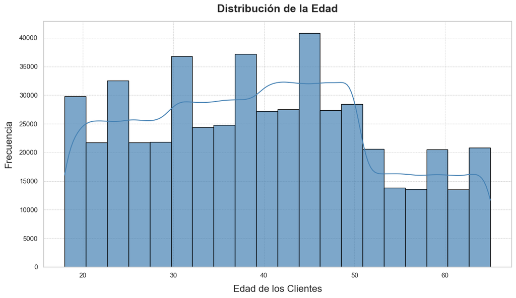

En el gráfico de distribución de edades, se observa que los clientes se concentran mayoritariamente en el rango de **20 a 50 años**, con picos destacados en los **30 y 40 años**. Esto indica una base de clientes en su mayoría joven a mediana edad, lo que podría reflejar las preferencias y necesidades propias de este grupo demográfico.

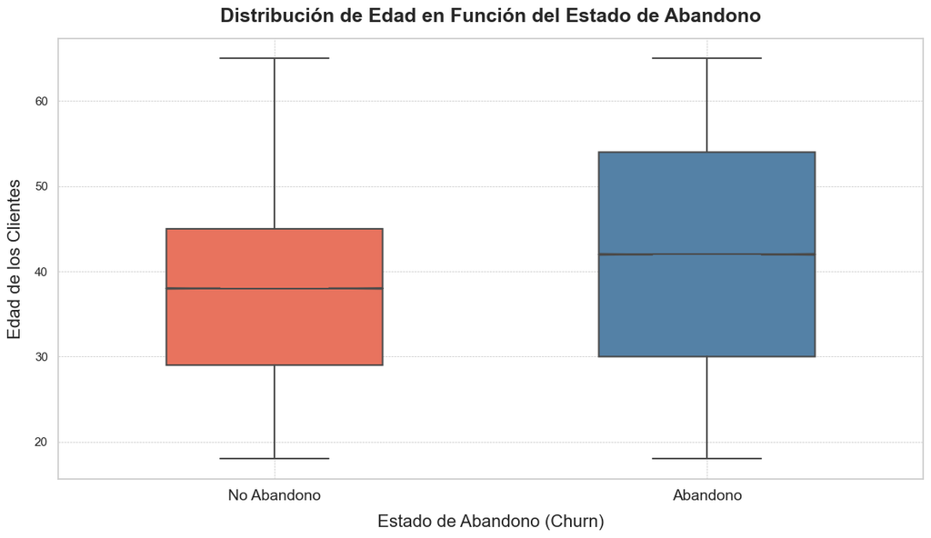

El gráfico muestra la distribución de la edad en función del estado de abandono. Se observa que los clientes que abandonan tienden a tener una edad promedio más alta en comparación con aquellos que no lo hacen.

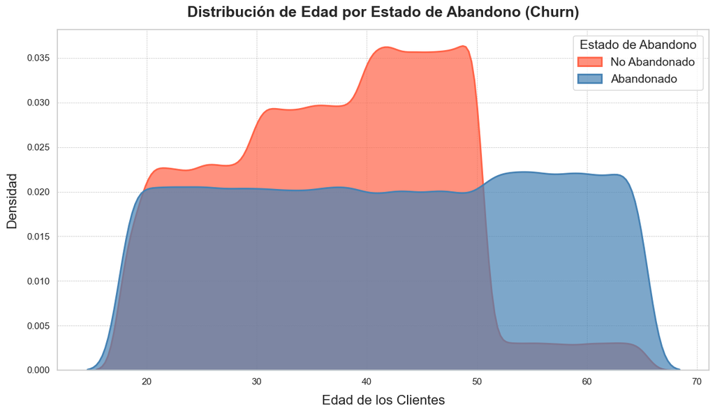

En el gráfico de densidad de edad por estado de abandono, se observa que los clientes entre los **30 y 50 años** presentan una mayor densidad en el grupo de no abandono, indicando una mayor fidelidad en este rango de edad.

Por otro lado, en los extremos de edad, especialmente cerca de los **20 años** y más allá de los **50 años**, se aprecia una mayor densidad en el grupo de abandono, lo que podría indicar una menor afinidad o satisfacción en estos grupos etarios.

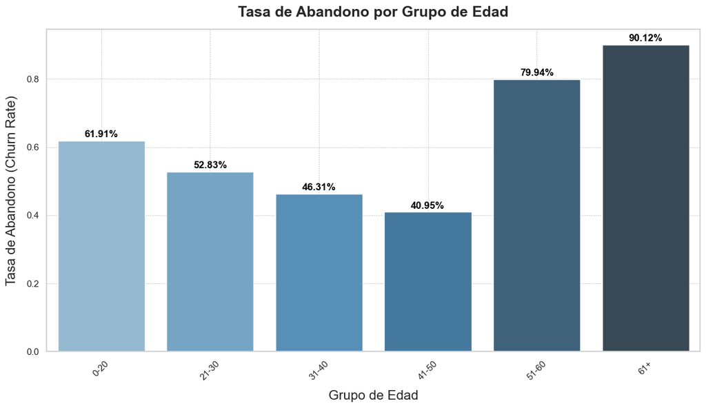

En el gráfico de tasas de abandono por grupo de edad, se observa lo siguiente:

**Clientes jóvenes (0-20 años):** Presentan una tasa de abandono alta del **61.91%**, lo que indica una posible falta de compromiso o alineación con sus expectativas. Este grupo podría beneficiarse de estrategias que incrementen el valor percibido, como beneficios exclusivos o planes adaptados.

**Grupo de 21-30 años:** La tasa de abandono desciende al **52.83%**, pero sigue siendo relativamente alta. Este segmento podría requerir campañas que fortalezcan la relación con la marca, destacando la conveniencia y el valor.

**Grupo de 41-50 años:** Con un **40.95%**, representa el punto más estable en términos de abandono. Las estrategias podrían enfocarse en reforzar la experiencia actual para mantener esta tendencia.

**Clientes de 51-60 años:** Mostraron una tasa significativamente alta del **79.94%**, lo que evidencia posibles problemas relacionados con el servicio o la percepción de valor. Este grupo podría beneficiarse de soporte personalizado y ofertas específicas que aborden sus necesidades.

**Clientes de 61 años o más:** Este grupo destaca con una tasa alarmante del **90.12%**, lo que indica la necesidad de una revisión profunda de la propuesta de valor para este segmento. Podrían requerirse ajustes significativos en los productos o servicios para atender mejor sus expectativas.

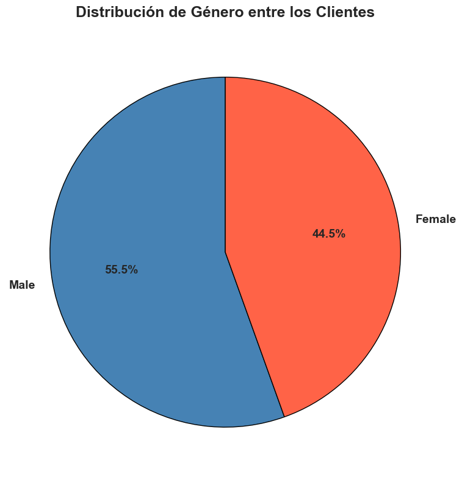

El gráfico muestra la distribución de género entre los clientes, donde **55.5%** son hombres (**Male**) y **44.5%** son mujeres (**Female**).

Esto evidencia que ambos géneros están bien representados, aunque existe una ligera predominancia de clientes masculinos en la base de datos. Este equilibrio relativo sugiere que las estrategias de marketing y comunicación deben considerar las preferencias de ambos géneros para maximizar su efectividad.

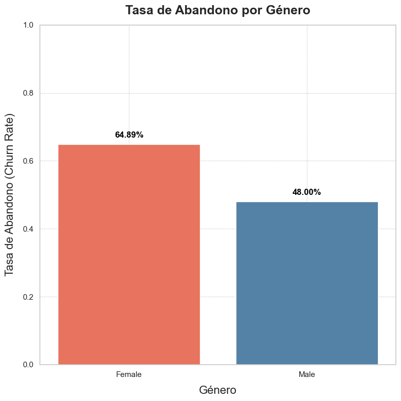

El gráfico muestra la tasa de abandono segmentada por género:

**Mujeres (Female):** Presentan una tasa de abandono del **64.89%**, significativamente más alta que la de los hombres. Esto sugiere que las mujeres podrían estar experimentando una menor satisfacción con el servicio o encontrar menos valor en la oferta actual.

**Hombres (Male):** Tienen una tasa de abandono menor, del **48.00%**, lo que indica una mayor estabilidad en este grupo. Sin embargo, aún existe margen para implementar estrategias que fortalezcan su lealtad.

**La tasa de abandono más alta en mujeres** sugiere que este grupo podría beneficiarse de una estrategia de retención más activa.

**La menor tasa de abandono en hombres** indica una mayor estabilidad en este segmento. Aún así, se pueden considerar estrategias de fidelización para aumentar aún más la lealtad de estos clientes y fortalecer su relación a largo plazo con la marca.

Dado que ambos géneros están bien representados en la base de clientes, pero con una ligera predominancia masculina, podría ser efectivo personalizar las campañas de marketing y la comunicación según el género.

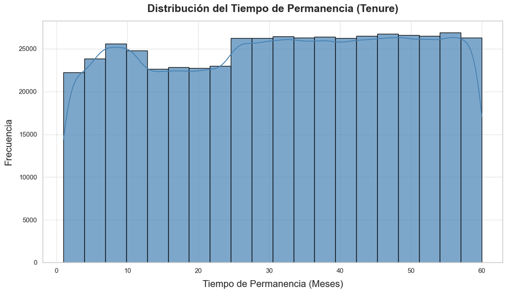

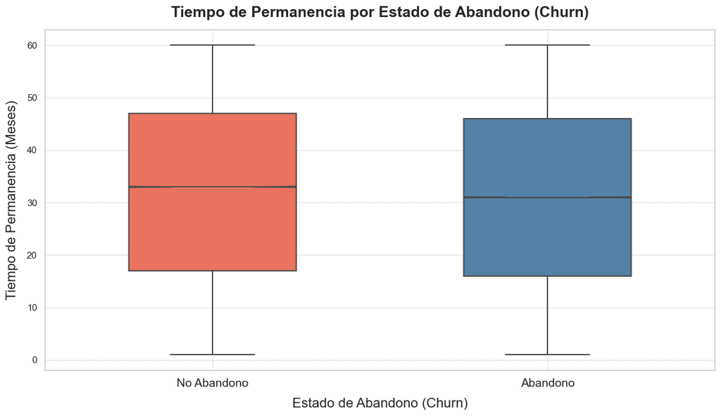

El siguiente gráfico muestra la distribución del tiempo de permanencia según el estado de abandono:

**Clientes que no abandonan:** Presentan un rango más amplio de tiempo de permanencia, con una mediana alrededor de **30 meses**, lo que sugiere una relación más estable y prolongada con el servicio.

**Clientes que abandonan:** Aunque la mediana es similar, hay un nivel de concentración de estos clientes en los primeros meses de permanencia, indicando una tendencia a abandonar en las etapas iniciales del servicio.

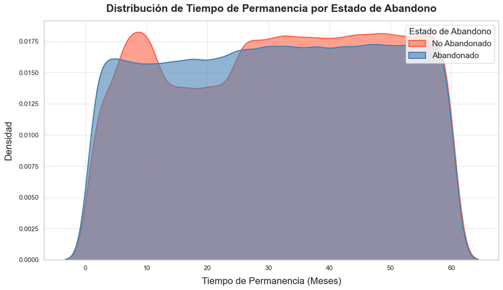

El gráfico muestra la distribución de densidad del tiempo de permanencia según el estado de abandono:

Ambos grupos, tanto los clientes que abandonan como los que permanecen, presentan distribuciones similares a lo largo del tiempo de permanencia.  
Sin embargo, se observa una mayor concentración de clientes que abandonan en los primeros **20 meses** de permanencia, lo que podría sugerir que esta etapa inicial es crítica para la retención.

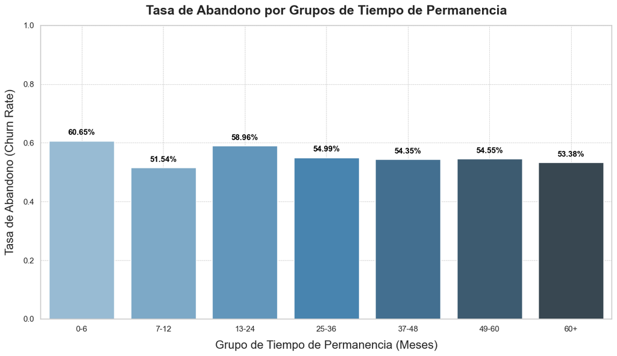

El gráfico analiza la tasa de abandono por grupos de tiempo de permanencia (**tenure**) en intervalos de meses:

**0-6 meses (60.65%):** Este grupo presenta la tasa de abandono más alta, lo que sugiere que los primeros meses son críticos. Este comportamiento podría estar relacionado con una expectativa inicial no cumplida o con la falta de conexión con el servicio. Es esencial enfocarse en un programa sólido de **onboarding**, con atención personalizada y comunicación proactiva durante este período.

**7-12 meses (51.54%):** La tasa de abandono disminuye significativamente, lo que indica que los clientes que superan la etapa inicial tienden a quedarse más tiempo. A pesar de esto, aún existe una oportunidad para optimizar el servicio y reforzar la relación en esta etapa.

**13-24 meses (58.96%):** El abandono vuelve a incrementarse, lo que podría reflejar problemas relacionados con el desgaste del servicio o la falta de incentivos para la permanencia a mediano plazo. Este grupo se beneficiaría de campañas de renovación o programas de fidelización que mantengan el interés y la percepción de valor.

**25-60 meses (54%-55%):** En este rango, las tasas de abandono se estabilizan, lo que sugiere que los clientes más longevos presentan una mayor fidelidad. Sin embargo, aún existen oportunidades para reducir esta tasa mediante el fortalecimiento de la relación a largo plazo, como beneficios exclusivos para clientes leales.

**60+ meses (53.38%):** Aunque es el grupo con una de las tasas de abandono más bajas, sugiere que incluso los clientes más antiguos no están completamente inmunes al abandono. Ofrecer incentivos para estos clientes, como descuentos o actualizaciones de servicio, podría prolongar su relación.

**Conclusiones:**

1. Los primeros 6 meses son el período más crítico, por lo que las estrategias deben centrarse en fortalecer la experiencia inicial del cliente.
2. La tasa de abandono en el rango de 13-24 meses indica que es crucial ofrecer incentivos específicos para los clientes a mediano plazo.
3. A pesar de una estabilización de las tasas en períodos más largos, las estrategias de retención a largo plazo, como programas de fidelización y beneficios exclusivos, siguen siendo necesarias para mantener a los clientes comprometidos.

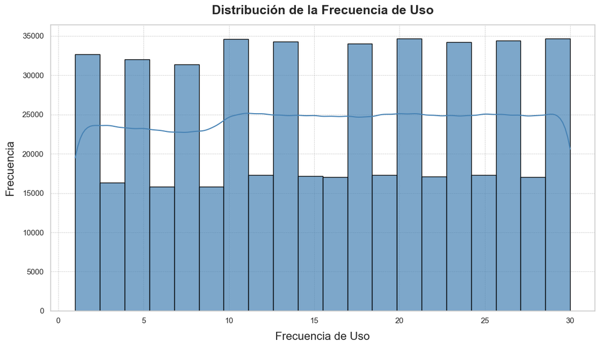

El gráfico muestra la distribución de la frecuencia de uso entre todos los clientes. Se observa una distribución relativamente uniforme a lo largo de los distintos valores de frecuencia, con ligeras variaciones en ciertos puntos.

**Observaciones:**

- La homogeneidad en el uso del servicio indica que no hay grupos significativamente diferenciados en términos de intensidad de uso.
- Esto sugiere que el servicio está siendo utilizado de manera consistente por la mayoría de los clientes, sin grandes concentraciones en extremos de alta o baja frecuencia.
- Este patrón puede ser beneficioso, ya que indica una base de usuarios bien distribuida, pero también plantea oportunidades para identificar subgrupos que puedan necesitar estímulos para aumentar su frecuencia de uso o fidelización.

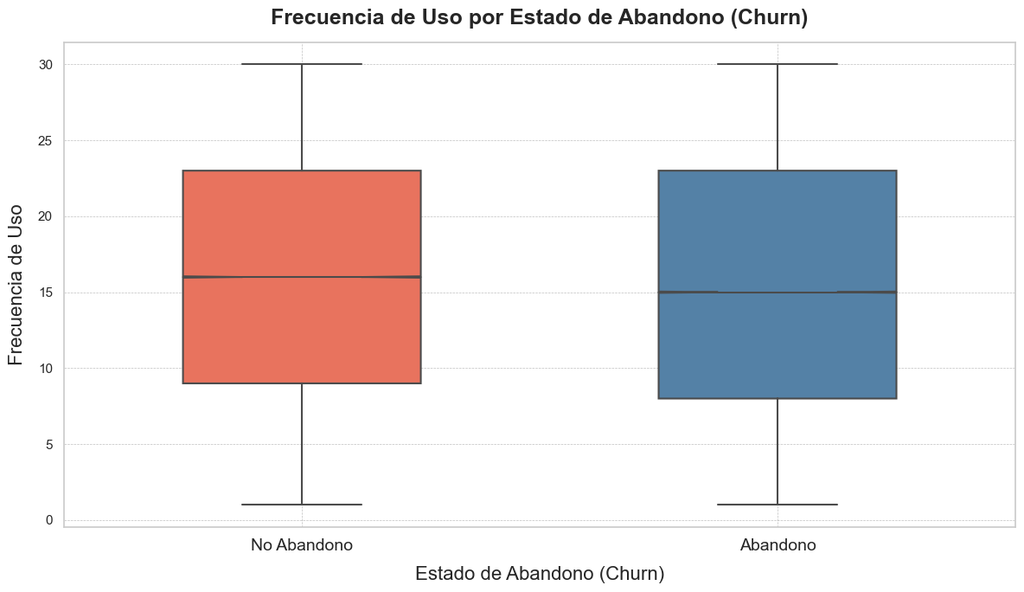

En el gráfico de comparación de la frecuencia de uso entre clientes que han abandonado y aquellos que permanecen:

**Observaciones:**

- Ambos grupos muestran una distribución similar, con rangos intercuartílicos y medianas muy cercanas.
- No se observa una diferencia significativa en la frecuencia de uso que pueda relacionarse directamente con la decisión de abandonar el servicio.

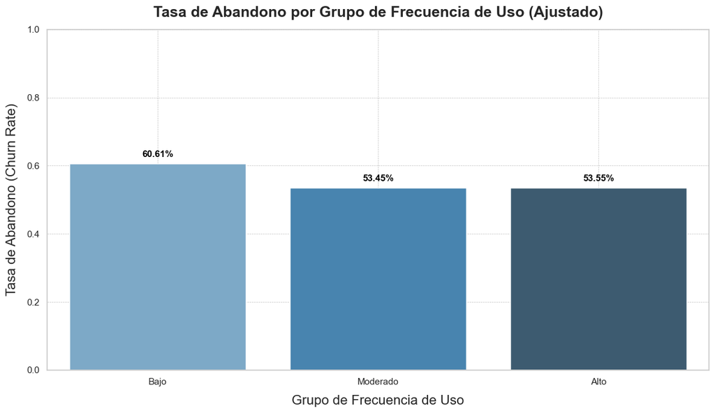

En este gráfico se segmenta la frecuencia de uso en tres grupos: **Bajo** (1-10), **Moderado** (11-20) y **Alto** (21-30), y se analiza su relación con la tasa de abandono:

**Bajo Uso (60.61%):** Este grupo presenta la tasa de abandono más alta, lo que indica una correlación significativa entre una baja frecuencia de uso y la probabilidad de abandono. Esto puede deberse a una falta de compromiso o interés en el servicio, lo que sugiere que estos clientes no encuentran suficiente valor para justificar su continuidad.

**Uso Moderado (53.45%) y Alto (53.55%):** Ambos grupos tienen tasas de abandono similares, significativamente menores que el grupo de bajo uso. Esto sugiere que los clientes con un mayor nivel de interacción con el servicio tienen una menor probabilidad de abandonar, posiblemente porque perciben un mayor valor o están más comprometidos.

**Conclusiones:**  
La baja frecuencia de uso es un indicador clave de riesgo de abandono. Es crucial implementar estrategias de reactivación para los clientes en este grupo, como notificaciones proactivas, promociones personalizadas o contenido atractivo que incentive un mayor uso del servicio.

Aunque los clientes con uso moderado y alto tienen tasas de abandono más bajas, mantener su interés a largo plazo sigue siendo importante. Campañas de engagement continuo pueden ayudar a prevenir que estos clientes reduzcan su frecuencia de uso y pasen al grupo de bajo uso, lo que aumentará su riesgo de abandono.

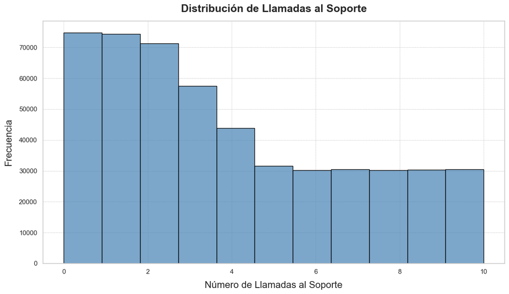

El gráfico muestra la distribución de la frecuencia de llamadas al soporte:

**Observaciones:**

Este patrón indica que la interacción con el soporte es generalmente baja, lo que podría ser positivo si refleja una experiencia de servicio sin problemas para la mayoría de los clientes.

Sin embargo, aquellos que realicen un mayor número de llamadas podrían estar experimentando problemas persistentes o insatisfacción, lo cual podría ser un factor de riesgo de abandono.

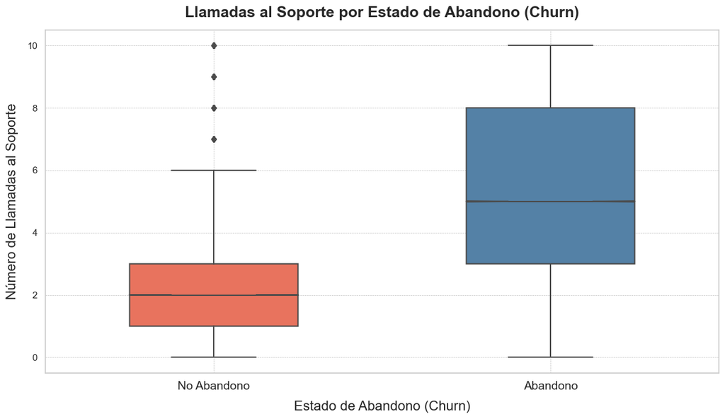

El gráfico muestra una clara diferencia en el número de llamadas al soporte entre los clientes que han abandonado y aquellos que no:

**Clientes que no abandonan:** Tienen un número de llamadas al soporte significativamente menor, con una mediana alrededor de **1-2 llamadas**. Esto sugiere que estos clientes probablemente encuentren menos problemas o tengan una experiencia más satisfactoria con el servicio.

**Clientes que abandonan:** Presentan un mayor número de llamadas al soporte, con una mediana más alta y un rango más amplio. Esto sugiere que estos clientes pueden estar experimentando problemas más frecuentes o no resueltos, lo que podría conducir a su insatisfacción y eventual abandono.

Una frecuencia alta de llamadas al soporte parece estar correlacionada con el abandono, lo que indica que estos clientes podrían encontrarse enfrentando problemas no resueltos o una experiencia de soporte poco satisfactoria.

La percepción de la calidad del soporte puede ser un factor determinante en la retención de clientes.

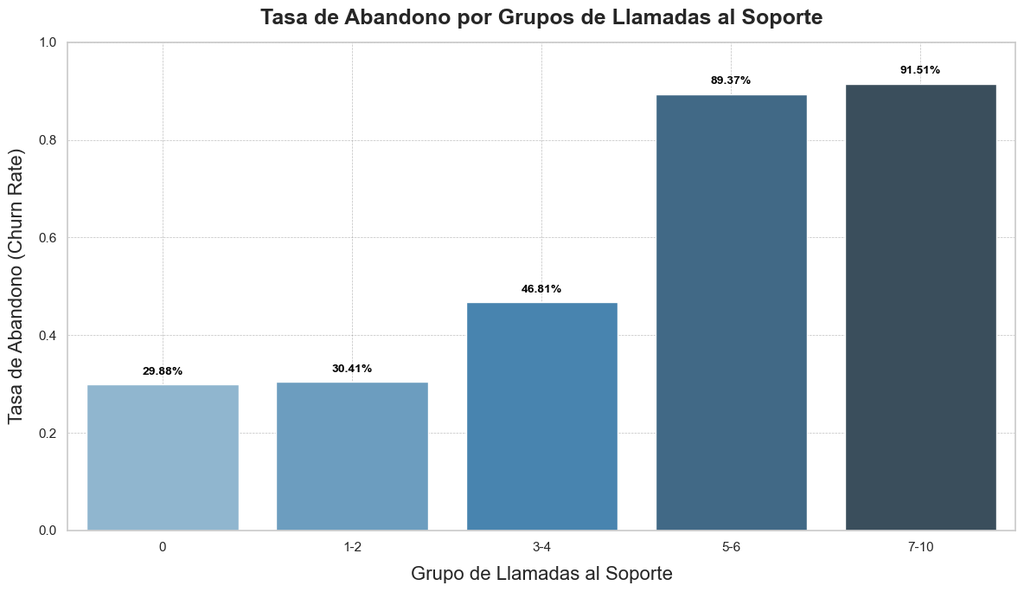

El gráfico muestra cómo la tasa de abandono aumenta significativamente con el número de llamadas al soporte:

**0-2 llamadas:** Los clientes que no llaman o llaman entre 1 y 2 veces tienen una tasa de abandono baja, en torno al **30%**, lo que indica que probablemente no enfrentan problemas importantes o que sus problemas fueron resueltos de manera efectiva en sus pocas interacciones con el soporte.

**3-4 llamadas:** La tasa de abandono aumenta excesivamente al **46.81%**, lo que podría reflejar una insatisfacción creciente debido a problemas persistentes o a una resolución ineficaz de sus inquietudes.

**5-6 llamadas:** Aquí, la tasa de abandono se dispara al **89.37%**, indicando que los clientes que tienen que recurrir frecuentemente al soporte probablemente enfrentan problemas no resueltos que afectan significativamente su percepción del servicio.

**7-10 llamadas:** La tasa de abandono alcanza una alarmante **91.51%**, mostrando que una alta frecuencia de llamadas al soporte es un indicador crítico de insatisfacción y abandono inminente.

Existe una aceleración directa y fuerte entre el número de llamadas al soporte y la probabilidad de abandono. Este comportamiento resalta que múltiples llamadas no solo reflejan problemas, sino que también indican que estas no están siendo resueltas de manera adecuada o rápida.

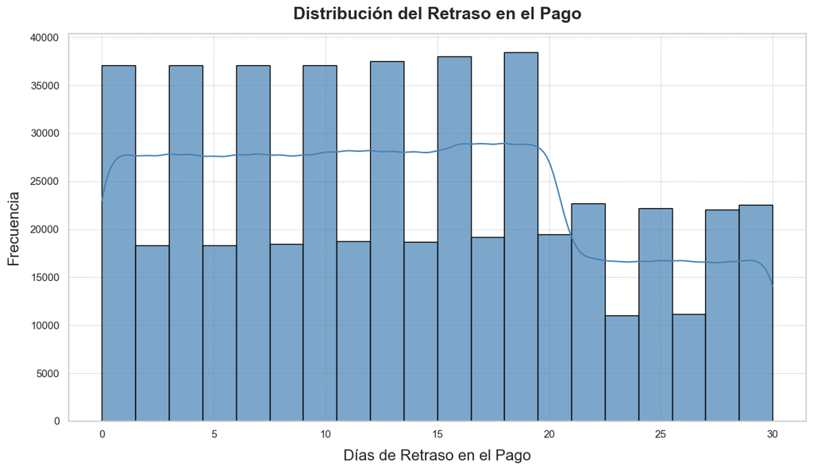

El gráfico muestra la distribución de los días de retraso en los pagos:

**Uniformidad en los primeros 20 días:** La mayoría de los clientes tienden a tener retrasos que se distribuyen de manera uniforme dentro de los primeros **20 días**, lo que sugiere que los retrasos moderados son comunes.

**Descenso a partir de los 20 días:** A medida que el retraso en los pagos se acerca al límite de **30 días**, hay una disminución en el número de clientes que retrasan sus pagos, lo que indica que los retrasos prolongados son menos frecuentes.

Los retrasos en los pagos son una práctica relativamente común, pero no suelen extenderse más allá de los **20 días** para la mayoría de los clientes.

Este comportamiento podría estar relacionado con factores como dificultades temporales de liquidez o falta de recordatorios efectivos para los pagos.

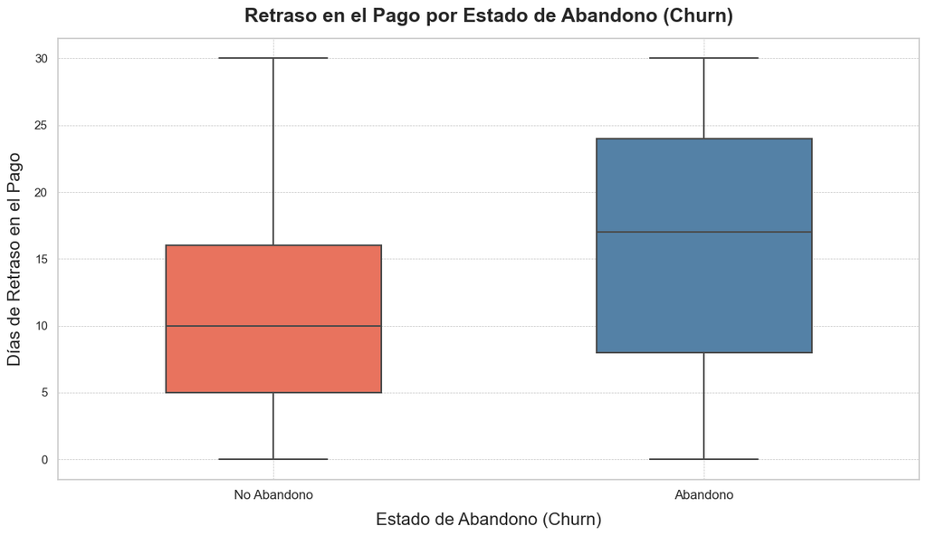

El boxplot muestra una clara diferencia en el retraso en el pago entre los clientes que abandonan y los que permanecen:

**Clientes que no abandonan:** Tienen una mediana de retraso más baja, generalmente dentro de un rango moderado, lo que indica que suelen cumplir con los pagos de manera más regular.

**Clientes que abandonan:** Presentan una mediana significativamente más alta y un rango de retrasos mucho mayor. Esto sugiere que los retrasos prolongados en los pagos pueden estar relacionados con la insatisfacción o dificultades financieras que eventualmente llevan al abandono.

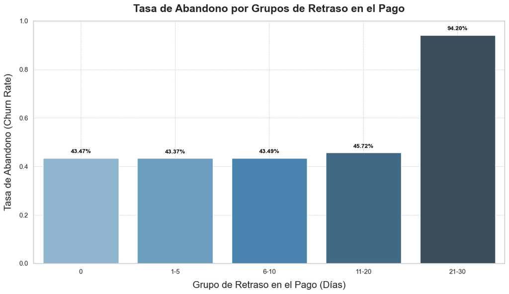

El gráfico muestra una relación clara entre los días de retraso en el pago y la tasa de abandono:

**Retrasos de 0 a 20 días:** La tasa de abandono es relativamente estable, oscilando alrededor del **43%** al **46%**. Esto sugiere que retrasos moderados no son un indicador crítico de abandono, pero aún representan un área de oportunidad para mejorar la retención.

**Retrasos de 21 a 30 días:** La tasa de abandono se dispara al **94.20%**, lo que indica que los retrasos prolongados en los pagos son un fuerte predictor de abandono y reflejan un estado crítico de insatisfacción o dificultades económicas.

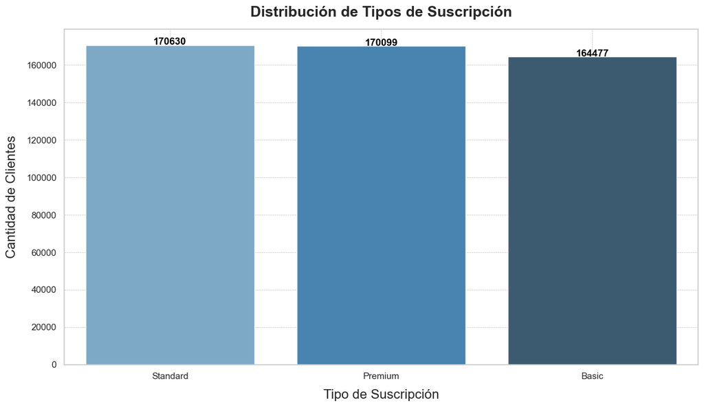

El gráfico muestra la distribución de los tres tipos de suscripción entre los clientes:

**Estándar:** Es el tipo de suscripción más común, con **170,630 clientes**, seguido muy de cerca por **Premium**, con **170,099 clientes**. **Básico**, es ligeramente menos popular, con **164,477 clientes**.

La distribución es bastante equilibrada entre los diferentes tipos de suscripción, lo que sugiere que todos los planes tienen una aceptación similar. Esto facilita una comparación justa al analizar cómo cada tipo de suscripción puede impactar en métricas clave como la tasa de abandono (**churn**).

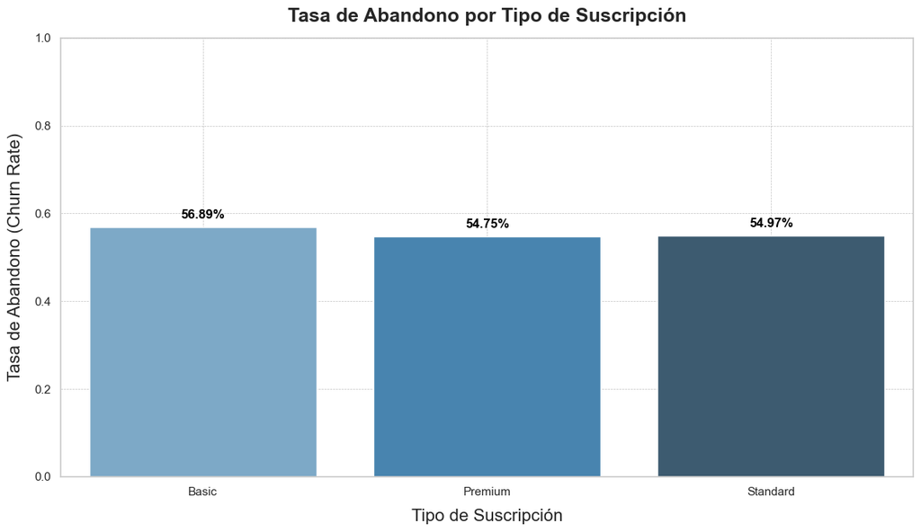

El gráfico revela la tasa de abandono (**churn**) para cada tipo de suscripción:

**Básico (56.89%):** Este grupo tiene la tasa de abandono más alta, lo que sugiere que los clientes con este tipo de suscripción pueden estar menos satisfechos o comprometidos con el servicio.

**Premium (54.75%) y Standard (54.97%):** Ambos presentan tasas de abandono ligeramente menores y muy similares entre sí, lo que indica que las suscripciones con más beneficios podrían estar reteniendo a los clientes de manera más efectiva.

Aunque las diferencias no son grandes, los clientes con suscripción **Básico** tienen una mayor tendencia a abandonar el servicio. Esto puede deberse a un menor valor percibido o a expectativas no satisfechas en comparación con los planes de mayor nivel.

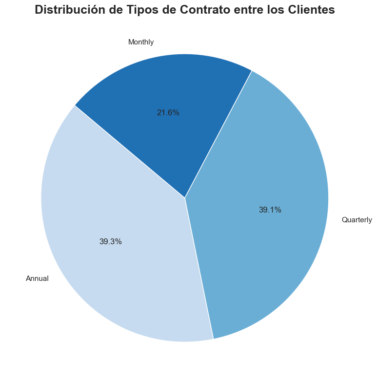

El gráfico de distribución de tipos de contrato muestra la siguiente segmentación entre los clientes:

**Contratos Anuales (39.3%):** Es el tipo de contrato más popular, lo que sugiere que una gran parte de los clientes prefiere compromisos a largo plazo, posiblemente debido a descuentos u otros beneficios asociados.

**Contratos Trimestrales (39.1%):** Muy cercano al contrato anual en popularidad, esto indica que otra gran parte de los clientes también valora compromisos intermedios que ofrecen flexibilidad con beneficios competitivos.

**Contratos Mensuales (21.6%):** Es la opción menos popular, lo que podría deberse a que no ofrece incentivos tan atractivos como las opciones a mayor plazo.

La mayoría de los clientes optan por contratos de mayor duración, lo que refleja una preferencia por planes con beneficios financieros a largo plazo. Sin embargo, una proporción significativa de clientes también prefiere contratos mensuales, posiblemente debido a la flexibilidad que estos ofrecen.

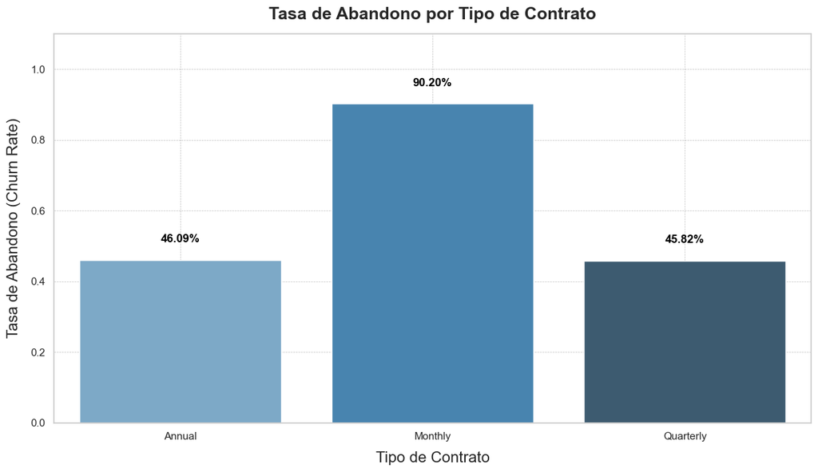

El gráfico destaca una fuerte relación entre el tipo de contrato y la tasa de abandono:

**Contratos Mensuales (90.20%):**  
Este grupo muestra la tasa de abandono más alta, lo que indica que los clientes con esta modalidad son los más propensos a cancelar el servicio.  
Los contratos mensuales parecen ser menos efectivos en retener clientes, posiblemente debido a la falta de compromiso o incentivos para permanecer.

**Contratos Trimestrales (45.82%) y Anuales (46.09%):**  
Ambos presentan tasas de abandono significativamente más bajas, lo que sugiere que los contratos de mayor duración están asociados con una mayor retención de clientes.  
Los clientes con contratos a más largo plazo podrían estar más satisfechos o sentir que reciben mayor valor por el servicio.

La alta tasa de abandono en contratos mensuales resalta la necesidad de intervenir en este segmento. Por otro lado, los contratos trimestrales y anuales son efectivos en reducir el abandono, reflejando un mayor compromiso de los clientes.

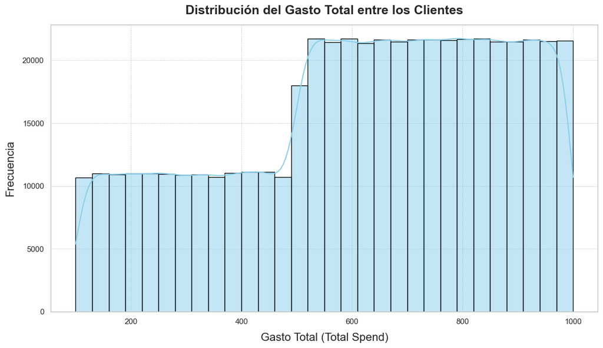

El gráfico de distribución del **Gasto Total (Total Spend)** revela lo siguiente:

**Distribución uniforme en los niveles bajos:**  
En los rangos más bajos de gasto, la distribución es relativamente uniforme, lo que indica que existe una base considerable de clientes que realizan un gasto moderado.

**Incremento en el rango medio alto:**  
A medida que nos acercamos a los rangos de gasto medio y alto, se observa un aumento en la frecuencia, lo que indica que una parte significativa de los clientes se encuentra en este nivel.

El gasto total está predominantemente concentrado en los niveles medio y alto, lo que sugiere que los clientes en estos rangos contribuyen de manera significativa al ingreso general. Sin embargo, los niveles bajos también representan una porción importante de la base de clientes.

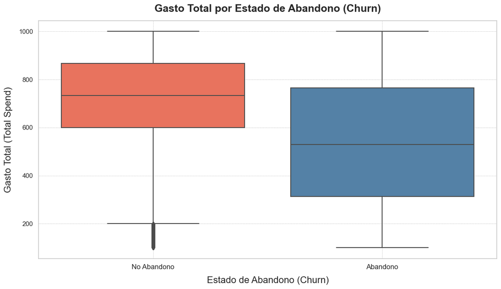

El gráfico boxplot muestra una clara relación entre el gasto total y el estado de abandono:

**Clientes que no abandonan:**  
Estos clientes tienden a tener un gasto total significativamente más alto, con una mediana superior y menos valores en el rango bajo.  
Esto sugiere que los clientes que invierten más en el servicio están más comprometidos y satisfechos, lo que reduce su probabilidad de abandono.

**Clientes que abandonan:**  
Presentan un gasto total más bajo, con una mediana notablemente inferior y un rango de valores concentrado en niveles moderados y bajos.  
Esto puede indicar que estos clientes no perciben suficiente valor en el servicio en relación con su inversión.

El gasto total es un posible indicador de retención de clientes. Aquellos con mayores niveles de gasto están menos inclinados a abandonar el servicio, lo que podría deberse a un mayor compromiso, percepción de valor o beneficios percibidos.

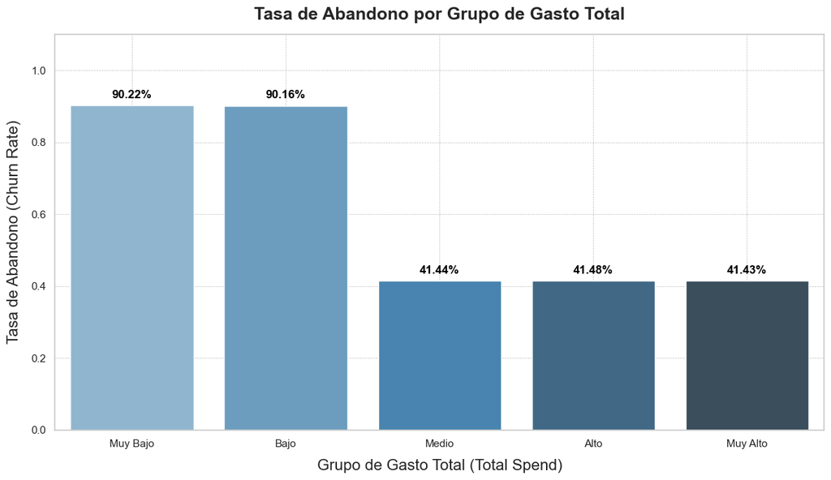

El análisis de la tasa de abandono por grupo de gasto total revela patrones claros en la retención de clientes:

**Clientes con gasto Muy Bajo y Bajo:**  
Presentan tasas de abandono extremadamente altas (**90.22%** y **90.16%**), lo que indica una relación directa entre bajo gasto e insatisfacción o desconexión con el servicio.  
Es un segmento crítico que necesita atención inmediata para reducir el abandono.

**Clientes con gasto Medio, Alto y Muy Alto:**  
A partir del gasto medio, las tasas de abandono caen excesivamente y se estabilizan alrededor del **41%**.  
Esto muestra que los clientes que invierten más en el servicio tienden a estar más comprometidos o satisfechos.

El gasto total es un indicador clave del riesgo de abandono. Los clientes en los segmentos de gasto más bajo tienen mayor probabilidad de abandonar, mientras que un mayor gasto parece correlacionarse con una mejor retención.

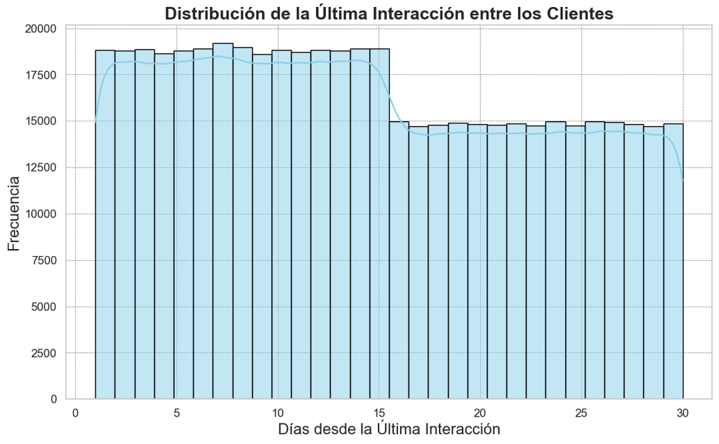

El gráfico ilustra la distribución de los días transcurridos desde la última interacción de los clientes. Los hallazgos clave son:

**Interacciones recientes predominantes:**  
La mayoría de los clientes ha interactuado recientemente, concentrándose principalmente en los primeros **15 días**.  
Esto sugiere una alta actividad inicial o una respuesta efectiva a interacciones recientes por parte de la empresa.

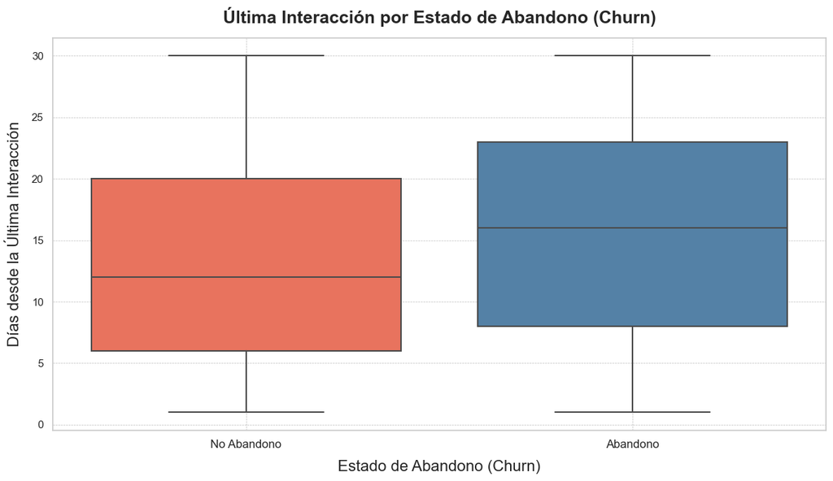

El gráfico muestra la relación entre los días desde la última interacción y el estado de abandono (**Churn**). Al observar los datos actualizados, se identifican los siguientes patrones:

Existe una clara distinción en la frecuencia de interacción entre ambos grupos. Los clientes que abandonan tienden a interactuar con menor frecuencia con el servicio antes de tomar la decisión de abandonarlo.

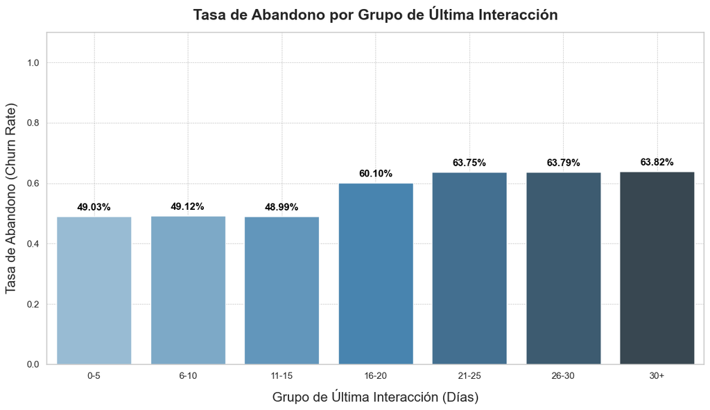

**Grupos con interacciones recientes (0-15 días):** - **Tasa de abandono estable:** Los clientes que han interactuado en los últimos **15 días** presentan una tasa de abandono estable y relativamente baja, en torno al **49%**. - Las interacciones recientes ayudan a retener a los clientes y mantenerlos comprometidos con el servicio.

**Grupos con interacciones más lejanas (16-30+ días):**

- **Aumento notable de abandono:** A partir de los **16 días** sin interacción, la tasa de abandono aumenta significativamente, superando el **60%** en los grupos de **16-20 días**, y alcanzando hasta el **63.8%** en los clientes que llevan más de **30 días** sin interactuar.
- Este comportamiento sugiere que la falta de interacción prolongada es un fuerte indicador de insatisfacción o desconexión del cliente con el servicio.

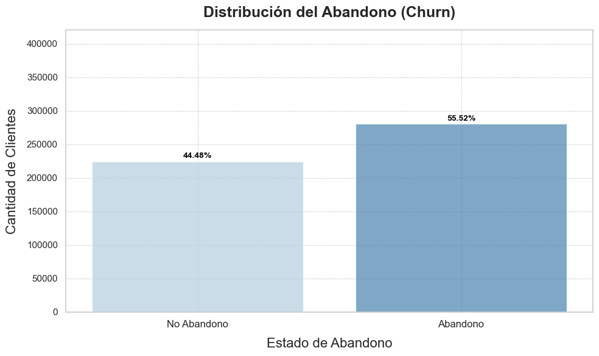

El análisis de la variable **"churn"** refleja que el **55.52%** de los clientes han abandonado el servicio, mientras que el **44.48%** permanecen activos.

**Alta tasa de abandono:**

- Con más de la mitad de los clientes abandonando, esto indica un problema estructural que debe abordarse de manera prioritaria.
- La empresa enfrenta desafíos significativos relacionados con la retención de clientes, lo cual afecta directamente los ingresos recurrentes y la sostenibilidad del negocio.

**Diferencia entre retención y abandono:**

- Aunque la proporción de clientes activos es considerable, el desequilibrio sugiere la necesidad de estrategias enfocadas en mejorar la experiencia del cliente, reducir la fricción en el servicio y fomentar la fidelidad.

### 3.5 Matriz de Correlación

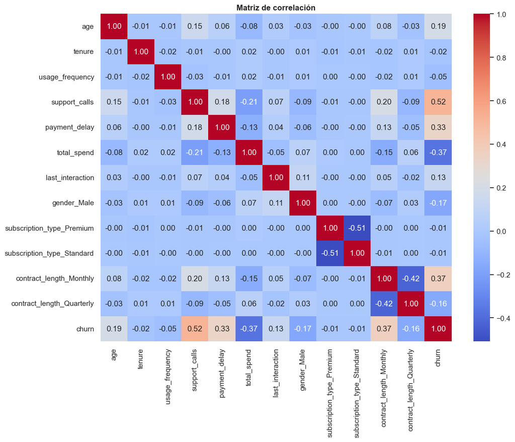

El foco de este análisis es la variable **abandono de clientes**, evaluando las variables que tienen una mayor correlación con ella y analizando el sentido de esta relación.

### Variables más relevantes para el abandono

**Support_calls (Llamadas de soporte):**

- Correlación positiva de **0.52** con abandono.
- Esto indica que a medida que aumenta el número de llamadas al soporte, también aumenta la probabilidad de abandono. Esto sugiere que múltiples llamadas de soporte podrían ser un indicador de insatisfacción o problemas persistentes no resueltos.

**Payment_delay (Retraso en el pago):**

- Correlación positiva de **0.33** con abandono.
- Un retraso en los pagos está positivamente relacionado con el abandono, lo que indica que los clientes con problemas para pagar a tiempo tienen más probabilidades de cancelar su suscripción.

**Gasto_total (Gasto total):**

- Correlación negativa de **-0.37** con abandono.
- Los clientes con un gasto total más alto tienen menos probabilidades de abandonar. Esto podría deberse a una mayor satisfacción o percepción de valor por parte de los clientes que invierten más en el servicio.

**Contract_length_Monthly (Duración del contrato mensual):**

- Correlación positiva de **0.37** con abandono.
- Los contratos mensuales están asociados con una mayor probabilidad de abandono, posiblemente porque ofrecen más flexibilidad para cancelar en comparación con contratos más largos.

**Contract_length_Quarterly (Duración del contrato trimestral):**

- Correlación negativa de **-0.16** con abandono.
- Esto sugiere que los contratos trimestrales están relacionados con una menor probabilidad de abandono en comparación con los contratos mensuales.

**Edad (Edad):**

- Correlación positiva de **0.19** con abandono.
- Los clientes de mayor edad parecen tener una ligera tendencia a abandonar más.

**Gender_Male (Género masculino):**

- Correlación negativa de **-0.17** con abandono.
- Los hombres tienen una ligera tendencia a permanecer en el servicio en comparación con las mujeres.

**Last_interaction (Última interacción):**

- Correlación positiva de **0.13** con abandono.
- Esto sugiere que cuanto mayor es el tiempo desde la última interacción, mayor es la probabilidad de abandono, aunque el efecto es leve.

### Relaciones relevantes

**Llamadas de soporte y gasto total:**

- Correlación negativa de **-0.21**.
- Los clientes que gastan más suelen necesitar menos soporte, posiblemente porque experimentan menos problemas o tienen acceso a un mejor servicio.

**Duración del contrato mensual y llamadas de soporte:**

- Correlación positiva de **0.20**.
- Los clientes con contratos mensuales requieren más llamadas de soporte en comparación con aquellos con contratos más largos, lo que podría indicar una experiencia más problemática para este grupo.